# 02_Predict_Ethnicity

Victor Yuan

October 29, 2018

Here I implement nested cross validation to train an ethnicity classifier and evaluate performance of the classifier.

# 1.0 Setup

```r
library(minfi)
library(parallel)
library(doParallel)
library(e1071)
library(factoextra)
library(ggthemes)
library(RCurl)
library(methylkit) #install_github('wvictor14/methylkit', force=T)
library(pheatmap)
library(wateRmelon)
library(caret)
library(VennDiagram)
library(UpSetR)
library(tidyr)
library(pamr)
library(ggpubr)
library(ggsci)
library(dplyr)
library(impute)
library(ggridges)
library(sesame)
library(readxl)
source('../sscen.R')
```

## 1.1 load data

```r
betas <- readRDS('../../Robjects_final/01_processed_betas_EPIC.rds')
dim(betas) #  319233    510
```

```
## [1] 319233    510
```

```r
pDat <- readRDS('../../Robjects_final/01_pDat.rds')
dim(pDat) # 510 22
```

```
## [1] 510  22
```

Next I normalize the data without any filtering, so that I can use epistructure and Barfield’s methods with all of the relevant probes.

```r
#load raw mset data
mset <- readRDS('../../Robjects_final/00_mset_RCMFM_raw_eth.rds')
betas_all <- BMIQ(mset)
saveRDS(betas_all, '../../Robjects_final/02_BMIQ_nofiltering.rds')
```

```r
betas_all <- readRDS('../../Robjects_final/02_BMIQ_nofiltering.rds')
dim(betas_all) # 485577    518
```

```
## [1] 485577    518
```

```r
betas_all <- betas_all[,colnames(betas)]
dim(betas_all) # 485577    510
```

```
## [1] 485577    510
```

- remove nas (Here I use knn impute)
- transpose data and make dataframe (for caret)

```r
sum(is.na(betas));sum(is.na(betas_all))
```

```
## [1] 339
```

```
## [1] 848
```

```r
# knn impute
set.seed(1)
betas <- impute.knn(as.matrix(betas), maxp = 15000)$data
```

[output not shown]

[output cut: 59 more lines]

[output not shown]

```r
set.seed(1)
betas_all <- impute.knn(as.matrix(betas_all), maxp = 15000)$data
```

[output not shown]

[output cut: 122 more lines]

[output not shown]

```r
sum(is.na(betas));sum(is.na(betas_all))
```

```
## [1] 0
```

```
## [1] 0
```

```r
#transpose data
betas <- as.data.frame(t(betas))
betas_all <- as.data.frame(t(betas_all))
```

I remove south asian samples here

```r
ind <- which(pDat$Ethnicity == 'South_Asian')
pDat <- pDat[-ind,]
betas <- betas[-ind,]

pDat$Ethnicity2 <- gsub('East_', '', pDat$Ethnicity)
table(pDat$Ethnicity2) # 57        55       391
```

```
##
##   African     Asian Caucasian
##        57        55       391
```

```r
betas_all <- betas_all[pDat$sampleNames,]
```

Here I keep the replicate sample with the highest mean interarray correlation.

```r
# Identify replicates and then keep the one with highest correlation
# Here I pull out the replicates I don't want
reps_remove <- pDat %>% mutate(Case_ID = gsub('_r.*', '', sampleNames)) %>%
  group_by(Case_ID) %>% filter(n() > 1) %>%
  arrange(Case_ID, desc(meanSScor)) %>%
  slice(2:n()) %>% pull(sampleNames)

pDat <- pDat %>% filter(!sampleNames %in% reps_remove)
betas <- betas[pDat$sampleNames,]
betas_all <- betas_all[pDat$sampleNames,]

dim(pDat);dim(betas);dim(betas_all) # [1] 499  23 [1]    499 319233 [1]    499 485577
```

```
## [1] 499  23
```

```
## [1]    499 319233
```

```
## [1]    499 485577
```

# 2.0 Inner CV

This is where I build the predictors in the inner cross validation. The outer cross validation I reserve for evaluating the predictors.

```r
# Create outer fold sample indices
set.seed(10)

# Create outer fold sample indices
folds <- list(Fold1 = grep('Robinson', pDat$Dataset),
              Fold2 = grep('Cox', pDat$Dataset),
              Fold3 = grep('Marsit', pDat$Dataset),
              Fold4 = grep('Fry', pDat$Dataset),
              Fold5 = grep('Michels', pDat$Dataset))

# traincontrol
fitControl <- trainControl(method = "repeatedcv", number = 3, repeats = 10,
                           allowParallel = T, classProbs = T, returnData = F,
                           savePredictions = 'final', returnResamp = 'final',
                           summaryFunction = mnLogLoss)
```

## 2.1 Train / parameter tune

### GLMNET

GLMNET fitted over 48 combinations of alpha and lambda

```r
# configure parallel processing
cluster <- makeCluster(18) # ram is limiting
# at peak around 6.5 - 7 gb is used in an instance
registerDoParallel(cluster)

# create seeds for each resample
seeds <- list()
set.seed(11)
for (i in 1:length(folds)) {
  seeds[[paste0('fold', i)]] <- vector(mode = 'list', length = 10)
  for (j in 1:30) seeds[[paste0('fold', i)]][[j]] <- sample.int(1000, 48)
  seeds[[paste0('fold', i)]][[31]] <- sample.int(1000,1)
}

# tuning grid
glmGrid <-  expand.grid(alpha = c(0.025, 0.05, 0.1, 0.15, 0.2, 0.25, 0.3, 0.5),
                        lambda = c(0.0025, 0.005, 0.01, 0.05, 0.1, 0.25))

# train i glm_fit1 for i folds
glm_fit1 <- list()
system.time(
for (i in 1:length(folds)) {
  # set seed for resamples
  fitControl$seeds <- seeds[[paste0('fold', i)]]

  # inner cv / training
  glm_fit <- train(x = betas[-folds[[i]],], y = pDat$Ethnicity2[-folds[[i]]],
                 method = "glmnet",
                 metric = 'logLoss',
                 trControl = fitControl,
                 tuneGrid = glmGrid)
  glm_fit1[[paste0('fold', i)]] <- glm_fit;rm(glm_fit)
}
)#user  system elapsed
 #300.36  164.57 5274.27
stopCluster(cluster)
saveRDS(glm_fit1, '../../Robjects_final/02_innerCV_glm_fit_logloss.rds')
```

### SVM

```r
cluster <- makeCluster(14)
# 16 cores consumes ~90% of hpc01 ram
# at peak around 11 gb for 1 instance
registerDoParallel(cluster)

# SVM
seeds <- list()
set.seed(11)
for (i in 1:length(folds)) {
  seeds[[paste0('fold', i)]] <- vector(mode = 'list', length = 31)
  for (j in 1:30) seeds[[paste0('fold', i)]][[j]] <- sample.int(1000, 4)
  seeds[[paste0('fold', i)]][[31]] <- sample.int(1000,1)
}

svm_fit <- list()
system.time(
for (i in 1:length(folds)) {
  fitControl$seeds <- seeds[[paste0('fold', i)]]
  svm_fit1 <- train(x = betas[-folds[[i]],], y = pDat$Ethnicity2[-folds[[i]]],
                 method = "svmLinear",
                 metric = 'logLoss',
                 tuneGrid = data.frame(C = c(0.25, 1, 5, 20)),
                 trControl = fitControl)
  svm_fit[[paste0('fold', i)]] <- svm_fit1;rm(svm_fit1)
}
)# user   system  elapsed
# 3092.52   344.18 27610.45
stopCluster(cluster)
saveRDS(svm_fit, '../../Robjects_final/02_innerCV_svm_fit_logloss.rds')
```

### KNN

KNN from k = 1 to k = 10

```r
cluster <- makeCluster(14)
registerDoParallel(cluster)

# KNN
seeds <- list()
set.seed(111)
for (i in 1:length(folds)) {
  seeds[[paste0('fold', i)]] <- vector(mode = 'list', length = 16)
  for (j in 1:30) seeds[[paste0('fold', i)]][[j]] <- sample.int(1000, 10)
  seeds[[paste0('fold', i)]][[31]] <- sample.int(1000,1)
}
knn_fit <- list()
system.time(
for (i in 1:length(folds)) {
  fitControl$seeds <- seeds[[paste0('fold', i)]]
  knn_fit1 <- train(x = betas[-folds[[i]],], y = pDat$Ethnicity2[-folds[[i]]],
                   method = 'knn',
                   metric = 'logLoss',
                   tuneGrid = data.frame(k = seq(1,10, 1)),
                   trControl = fitControl)
  knn_fit[[paste0('fold', i)]] <- knn_fit1; rm(knn_fit1)
}
)# user   system  elapsed  (16 cores)
  #115.99   157.11 66293.92

stopCluster(cluster)
saveRDS(knn_fit, '../../Robjects_final/02_innerCV_knn_fit_logloss.rds')
```

### NSC

Nearest Shrunken Centroids

```r
cluster <- makeCluster(16)
registerDoParallel(cluster)

# create seeds for each resample
seeds <- list()
set.seed(11)
for (i in 1:length(folds)) {
  seeds[[paste0('fold', i)]] <- vector(mode = 'list', length = 10)
  for (j in 1:30) seeds[[paste0('fold', i)]][[j]] <- sample.int(1000, 81)
  seeds[[paste0('fold', i)]][[31]] <- sample.int(1000,1)
}

NSCGrid <- data.frame(threshold = seq(0,10, 0.125))

# train i glm_fit1 for i folds
nsc_fit <- list();set.seed(0)
system.time(
for (i in 1:length(folds)) {
  # set seed for resamples
  fitControl$seeds <- seeds[[paste0('fold', i)]]

  # inner cv / training
  nsc_fit1 <- train(x = betas[-folds[[i]],], y = pDat$Ethnicity2[-folds[[i]]],
                 method = "pam",
                 metric = 'logLoss',
                 trControl = fitControl,
                 tuneGrid = NSCGrid)
  nsc_fit[[paste0('fold', i)]] <- nsc_fit1;rm(nsc_fit1)
}
)#111   user  system elapsed (16 cores)
 # 251.94  333.25 8856.84
stopCluster(cluster)
saveRDS(nsc_fit, '../../Robjects_final/02_innerCV_nsc_fit_logLoss.rds')
```

```r
glm_fit1 <- readRDS('../../Robjects_final/02_innerCV_glm_fit_logloss.rds')
svm_fit <- readRDS('../../Robjects_final/02_innerCV_svm_fit_logloss.rds')
knn_fit <- readRDS('../../Robjects_final/02_innerCV_knn_fit_logloss.rds')
nsc_fit <- readRDS('../../Robjects_final/02_innerCV_nsc_fit_logLoss.rds')
```

## 2.2 Compare Parameter tuning

Here I examine the parameter tuning across all outer folds.

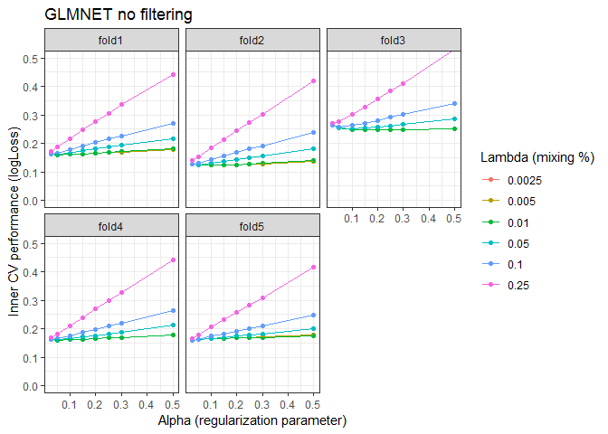

```r
# tuning parameters
res <- list(GLMNET =
  rbind(glm_fit1$fold1$results %>% mutate(fold = 'fold1'),
        glm_fit1$fold2$results %>% mutate(fold = 'fold2'),
        glm_fit1$fold3$results %>% mutate(fold = 'fold3'),
        glm_fit1$fold4$results %>% mutate(fold = 'fold4'),
        glm_fit1$fold5$results %>% mutate(fold = 'fold5')) %>% as_tibble(),
  KNN =
  rbind(knn_fit$fold1$results %>% mutate(fold = 'fold1'),
        knn_fit$fold2$results %>% mutate(fold = 'fold2'),
        knn_fit$fold3$results %>% mutate(fold = 'fold3'),
        knn_fit$fold4$results %>% mutate(fold = 'fold4'),
        knn_fit$fold5$results %>% mutate(fold = 'fold5')) %>% as_tibble(),
  NSC =
  rbind(nsc_fit$fold1$results %>% mutate(fold = 'fold1'),
        nsc_fit$fold2$results %>% mutate(fold = 'fold2'),
        nsc_fit$fold3$results %>% mutate(fold = 'fold3'),
        nsc_fit$fold4$results %>% mutate(fold = 'fold4'),
        nsc_fit$fold5$results %>% mutate(fold = 'fold5')) %>% as_tibble(),
#  rf =
#  rbind(rf_fit$fold1$results %>% mutate(fold = 'fold1'),
#        rf_fit$fold2$results %>% mutate(fold = 'fold2'),
#        rf_fit$fold3$results %>% mutate(fold = 'fold3')) %>% as_tibble(),
  SVM =
  rbind(svm_fit$fold1$results %>% mutate(fold = 'fold1'),
        svm_fit$fold2$results %>% mutate(fold = 'fold2'),
        svm_fit$fold3$results %>% mutate(fold = 'fold3'),
        svm_fit$fold4$results %>% mutate(fold = 'fold4'),
        svm_fit$fold5$results %>% mutate(fold = 'fold5')) %>% as_tibble())

ggplot(res$GLMNET , aes(x = alpha, y = logLoss, color = as.factor(lambda))) +
  geom_point()+ geom_line() + coord_cartesian(ylim = c(0,0.5)) +
  facet_wrap(~fold) +
  theme_bw() +
  labs(title = 'GLMNET no filtering', y = 'Inner CV performance (logLoss)',
       x = 'Alpha (regularization parameter)', color = 'Lambda (mixing %)')
```

```r
print('best alpha lambda:');print('fold1');
```

```
## [1] "best alpha lambda:"
```

```
## [1] "fold1"
```

```r
glm_fit1$fold1$bestTune;print('fold2:');glm_fit1$fold2$bestTune
```

```
##   alpha lambda
## 9  0.05   0.01
```

```
## [1] "fold2:"
```

```
##    alpha lambda
## 15   0.1   0.01
```

```r
print('fold3:');glm_fit1$fold3$bestTune
```

```
## [1] "fold3:"
```

```
##    alpha lambda
## 33  0.25   0.01
```

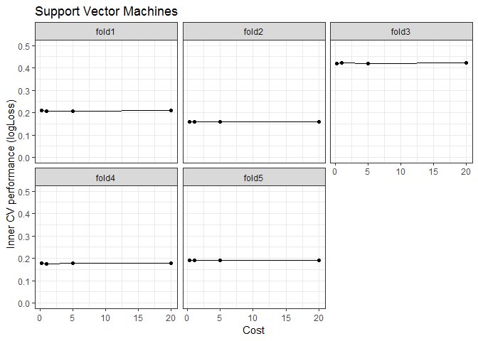

```r
ggplot(res$SVM , aes(x = C, y = logLoss)) +
  geom_point()+ geom_line() + coord_cartesian(ylim = c(0,0.5)) +
  facet_wrap(~fold) +
  theme_bw() +
  labs(title = 'Support Vector Machines', y = 'Inner CV performance (logLoss)',
       x = 'Cost')
```

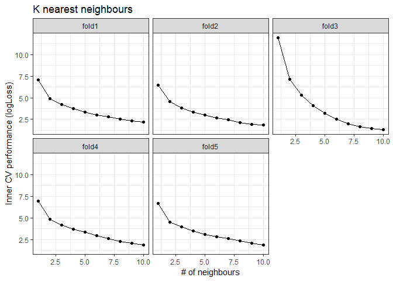

```r
ggplot(res$KNN , aes(x = k, y = logLoss)) +
  geom_point()+ geom_line() + coord_cartesian() +
  facet_wrap(~fold) +
  theme_bw() +
  labs(title = 'K nearest neighbours', y = 'Inner CV performance (logLoss)',
       x = '# of neighbours')
```

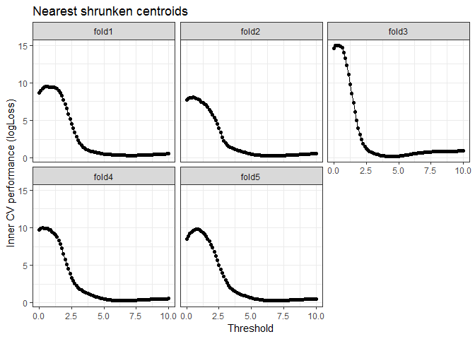

```r
ggplot(res$NSC , aes(x = threshold, y = logLoss)) +
  geom_point()+ geom_line() + coord_cartesian() +
  facet_wrap(~fold) +
  theme_bw() +
  labs(title = 'Nearest shrunken centroids', y = 'Inner CV performance (logLoss)',
       x = 'Threshold')
```

```r
#put best tune in table format
g <- rbind(
  glm_fit1$fold1$bestTune %>% as_tibble() %>% mutate(model = 'GLMNET', fold = 1),
  glm_fit1$fold2$bestTune %>% as_tibble() %>% mutate(model = 'GLMNET', fold = 2),
  glm_fit1$fold3$bestTune %>% as_tibble() %>% mutate(model = 'GLMNET', fold = 3),
  glm_fit1$fold4$bestTune %>% as_tibble() %>% mutate(model = 'GLMNET', fold = 4),
  glm_fit1$fold5$bestTune %>% as_tibble() %>% mutate(model = 'GLMNET', fold = 5))  %>%
    mutate(bestTune = paste0('alpha = ', alpha, ', lambda = ', lambda)) %>%
    select(model, fold, bestTune)

k <- rbind(
  knn_fit$fold1$bestTune %>% as_tibble() %>% mutate(model = 'KNN', fold = 1),
  knn_fit$fold2$bestTune %>% as_tibble() %>% mutate(model = 'KNN', fold = 2),
  knn_fit$fold3$bestTune %>% as_tibble() %>% mutate(model = 'KNN', fold = 3),
  knn_fit$fold4$bestTune %>% as_tibble() %>% mutate(model = 'KNN', fold = 4),
  knn_fit$fold5$bestTune %>% as_tibble() %>% mutate(model = 'KNN', fold = 5)) %>%
    mutate(bestTune = paste0('k = ', k)) %>%
    select(model, fold, bestTune)

s <- rbind(
  svm_fit$fold1$bestTune %>% as_tibble() %>% mutate(model = 'SVM', fold = 1),
  svm_fit$fold2$bestTune %>% as_tibble() %>% mutate(model = 'SVM', fold = 2),
  svm_fit$fold3$bestTune %>% as_tibble() %>% mutate(model = 'SVM', fold = 3),
  svm_fit$fold4$bestTune %>% as_tibble() %>% mutate(model = 'SVM', fold = 4),
  svm_fit$fold5$bestTune %>% as_tibble() %>% mutate(model = 'SVM', fold = 5)) %>%
    mutate(bestTune = paste0('Cost = ', C)) %>%
    select(model, fold, bestTune)
n <- rbind(
  nsc_fit$fold1$bestTune %>% as_tibble() %>% mutate(model = 'NSC', fold = 1),
  nsc_fit$fold2$bestTune %>% as_tibble() %>% mutate(model = 'NSC', fold = 2),
  nsc_fit$fold3$bestTune %>% as_tibble() %>% mutate(model = 'NSC', fold = 3),
  nsc_fit$fold4$bestTune %>% as_tibble() %>% mutate(model = 'NSC', fold = 4),
  nsc_fit$fold5$bestTune %>% as_tibble() %>% mutate(model = 'NSC', fold = 5)) %>%
    mutate(bestTune = paste0('Threshold = ', threshold)) %>%
    select(model, fold, bestTune)

bestTune <- rbind(g, k, n, s); rm(g,k,n,s)
bestTune
```

```
## # A tibble: 20 x 3
##    model   fold bestTune
##    <chr>  <dbl> <chr>
##  1 GLMNET     1 alpha = 0.05, lambda = 0.01
##  2 GLMNET     2 alpha = 0.1, lambda = 0.01
##  3 GLMNET     3 alpha = 0.25, lambda = 0.01
##  4 GLMNET     4 alpha = 0.05, lambda = 0.01
##  5 GLMNET     5 alpha = 0.025, lambda = 0.05
##  6 KNN        1 k = 10
##  7 KNN        2 k = 10
##  8 KNN        3 k = 10
##  9 KNN        4 k = 10
## 10 KNN        5 k = 10
## 11 NSC        1 Threshold = 7.125
## 12 NSC        2 Threshold = 6.5
## 13 NSC        3 Threshold = 4.375
## 14 NSC        4 Threshold = 6.5
## 15 NSC        5 Threshold = 6.75
## 16 SVM        1 Cost = 5
## 17 SVM        2 Cost = 1
## 18 SVM        3 Cost = 0.25
## 19 SVM        4 Cost = 1
## 20 SVM        5 Cost = 5
```

## 2.3 Compare Resampling results

Here I compare the performance of each Algorithm using the inner resampling performance across all outer folds.

```r
# start with a list of each model
resamp <- list(
  GLMNET =
  rbind(glm_fit1$fold1$resample %>% mutate(fold = 'Outer fold1'),
        glm_fit1$fold2$resample %>% mutate(fold = 'Outer fold2'),
        glm_fit1$fold3$resample %>% mutate(fold = 'Outer fold3'),
        glm_fit1$fold4$resample %>% mutate(fold = 'Outer fold4'),
        glm_fit1$fold5$resample %>% mutate(fold = 'Outer fold5')) %>% as_tibble(),
  NSC =
  rbind(nsc_fit$fold1$resample %>% mutate(fold = 'Outer fold1'),
        nsc_fit$fold2$resample %>% mutate(fold = 'Outer fold2'),
        nsc_fit$fold3$resample %>% mutate(fold = 'Outer fold3'),
        nsc_fit$fold4$resample %>% mutate(fold = 'Outer fold4'),
        nsc_fit$fold5$resample %>% mutate(fold = 'Outer fold5')) %>% as_tibble(),
  KNN =
  rbind(knn_fit$fold1$resample %>% mutate(fold = 'Outer fold1'),
        knn_fit$fold2$resample %>% mutate(fold = 'Outer fold2'),
        knn_fit$fold3$resample %>% mutate(fold = 'Outer fold3'),
        knn_fit$fold4$resample %>% mutate(fold = 'Outer fold4'),
        knn_fit$fold5$resample %>% mutate(fold = 'Outer fold5')) %>% as_tibble(),
  SVM =
  rbind(svm_fit$fold1$resample %>% mutate(fold = 'Outer fold1'),
        svm_fit$fold2$resample %>% mutate(fold = 'Outer fold2'),
        svm_fit$fold3$resample %>% mutate(fold = 'Outer fold3'),
        svm_fit$fold4$resample %>% mutate(fold = 'Outer fold4'),
        svm_fit$fold5$resample %>% mutate(fold = 'Outer fold5')) %>% as_tibble())

# take out resampling results from each Outer cv fold
x <- rbind(
  resamp$GLMNET %>% select(logLoss, fold) %>% mutate(Algorithm = 'GLMNET'),
  resamp$NSC %>% select(logLoss, fold) %>%
    mutate(Algorithm = 'NSC'),
  resamp$KNN %>% select(logLoss, fold) %>% mutate(Algorithm = 'KNN'),
  resamp$SVM %>% select(logLoss, fold) %>% mutate(Algorithm = 'SVM'))


y <- list()
for (i in 1:length(levels(as.factor(x$Algorithm)))){
  y[[i]] <- x %>%
    filter(Algorithm == levels(as.factor(x$Algorithm))[i]) %>%
    mutate(meanlogLoss = mean(logLoss)) %>%
    select(Algorithm, meanlogLoss) %>% slice(1)
}
meanK_Algorithm <- rbind(y[[1]], y[[2]], y[[3]], y[[4]]);rm(y)
meanK_Algorithm
```

```
## # A tibble: 4 x 2
##   Algorithm meanlogLoss
##   <chr>           <dbl>
## 1 GLMNET          0.170
## 2 KNN             1.82
## 3 NSC           NaN
## 4 SVM             0.231
```

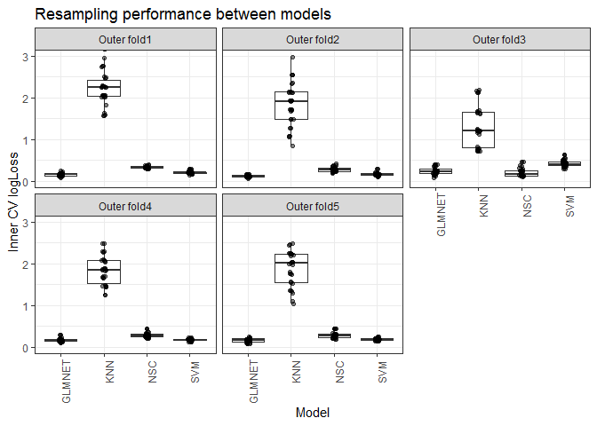

```r
ggplot(x, aes(x = Algorithm, y= logLoss)) +
  geom_boxplot(aes()) + geom_jitter(alpha = 0.5, width = 0.05)+
  #geom_point(position =position_jitterdodge(jitter.width = 0.05), alpha = 0.5)+
  coord_cartesian(ylim = c(0,3))+ facet_wrap(~fold) +
  theme_bw() + theme(axis.text.x=element_text(angle=90, hjust=0.95)) +
  labs(title = 'Resampling performance between models', x = 'Model',
       y = 'Inner CV logLoss')
```

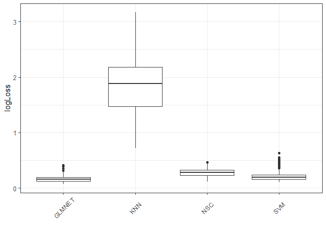

```r
p1 <- ggplot(x, aes(x = Algorithm, y= logLoss)) +
  geom_boxplot(aes()) +
  #geom_point(position =position_jitterdodge(jitter.width = 0.05), alpha = 0.5)+
  #coord_cartesian(ylim = c(0,1))+
  theme_bw(base_size = 12) +
  theme(legend.position="none", axis.text.x = element_text(angle = 45, vjust = 0.5)) +
  labs(x = '', y = 'logLoss')

p1
```

ggsave(plot = p1, filename = ‘../../Results/11_ResamplingPerformance_logloss.tiff’, height = 5, width = 4)

### significance test between errors

By comparing mean performance across all outer folds we can see that GLMNET beats all other classifiers, but is this statistically significant?

```r
wilcox.test(x %>% filter(Algorithm == 'GLMNET') %>% pull(logLoss),
            x %>% filter(Algorithm == 'SVM') %>% pull(logLoss),
            alternative = "two.sided")
```

```
##
##  Wilcoxon rank sum test with continuity correction
##
## data:  x %>% filter(Algorithm == "GLMNET") %>% pull(logLoss) and x %>% filter(Algorithm == "SVM") %>% pull(logLoss)
## W = 6657, p-value = 9.768e-10
## alternative hypothesis: true location shift is not equal to 0
```

```r
wilcox.test(x %>% filter(Algorithm == 'NSC') %>% pull(logLoss),
            x %>% filter(Algorithm == 'SVM') %>% pull(logLoss),
            alternative = "two.sided")
```

```
##
##  Wilcoxon rank sum test with continuity correction
##
## data:  x %>% filter(Algorithm == "NSC") %>% pull(logLoss) and x %>% filter(Algorithm == "SVM") %>% pull(logLoss)
## W = 13949, p-value = 1.676e-08
## alternative hypothesis: true location shift is not equal to 0
```

```r
wilcox.test(x %>% filter(Algorithm == 'NSC') %>% pull(logLoss),
            x %>% filter(Algorithm == 'GLMNET') %>% pull(logLoss),
            alternative = "two.sided")
```

```
##
##  Wilcoxon rank sum test with continuity correction
##
## data:  x %>% filter(Algorithm == "NSC") %>% pull(logLoss) and x %>% filter(Algorithm == "GLMNET") %>% pull(logLoss)
## W = 17018, p-value < 2.2e-16
## alternative hypothesis: true location shift is not equal to 0
```

The answer is GLMNET is statistically significantly better than NSC and SVM SVM is statistically better than NSC

Summary of performance

```r
s <- x %>% group_by(Algorithm) %>%
  summarize(mean_logLoss = mean(logLoss), sd_logLoss = sd(logLoss))
s;write.csv(s, '../../Results/11_resampling_performance_logloss.csv')
```

### Class skewing

Let’s look at how our unbalanced classes is handled by each Algorithmrithm

```r
#take out resampling predictions
cm_fold1 <- glm_fit1$fold1$pred %>% select(pred, obs) %>% table() %>%
  confusionMatrix
cm_fold2 <- glm_fit1$fold2$pred %>% select(pred, obs) %>% table() %>%
  confusionMatrix
cm_fold3 <- glm_fit1$fold3$pred %>% select(pred, obs) %>% table() %>%
  confusionMatrix
cm_fold4 <- glm_fit1$fold4$pred %>% select(pred, obs) %>% table() %>%
  confusionMatrix
cm_fold5 <- glm_fit1$fold5$pred %>% select(pred, obs) %>% table() %>%
  confusionMatrix
x <- data.frame(fold1 = cm_fold1$byClass[,1], fold2 = cm_fold2$byClass[,1],
                fold3 = cm_fold3$byClass[,1], fold4 = cm_fold4$byClass[,1],
                fold5 = cm_fold5$byClass[,1]) %>% t() %>%
  as.data.frame()%>%mutate(Algorithm = 'GLMNET', fold = c('fold1', 'fold2', 'fold3', 'fold4', 'fold5'))

cm_fold1 <- nsc_fit$fold1$pred %>% select(pred, obs) %>% table() %>%
  confusionMatrix
cm_fold2 <- nsc_fit$fold2$pred %>% select(pred, obs) %>% table() %>%
  confusionMatrix
cm_fold3 <- nsc_fit$fold3$pred %>% select(pred, obs) %>% table() %>%
  confusionMatrix
cm_fold4 <- nsc_fit$fold4$pred %>% select(pred, obs) %>% table() %>%
  confusionMatrix
cm_fold5 <- nsc_fit$fold5$pred %>% select(pred, obs) %>% table() %>%
  confusionMatrix
y <- data.frame(fold1 = cm_fold1$byClass[,1], fold2 = cm_fold2$byClass[,1],
                fold3 = cm_fold3$byClass[,1], fold4 = cm_fold4$byClass[,1],
                fold5 = cm_fold5$byClass[,1]) %>% t() %>%
  as.data.frame() %>% mutate(Algorithm = 'NSC', fold = c('fold1', 'fold2', 'fold3', 'fold4', 'fold5'))

cm_fold1 <- knn_fit$fold1$pred %>% select(pred, obs) %>% table() %>%
  confusionMatrix
cm_fold2 <- knn_fit$fold2$pred %>% select(pred, obs) %>% table() %>%
  confusionMatrix
cm_fold3 <- knn_fit$fold3$pred %>% select(pred, obs) %>% table() %>%
  confusionMatrix
cm_fold4 <- knn_fit$fold4$pred %>% select(pred, obs) %>% table() %>%
  confusionMatrix
cm_fold5 <- knn_fit$fold5$pred %>% select(pred, obs) %>% table() %>%
  confusionMatrix
k <- data.frame(fold1 = cm_fold1$byClass[,1], fold2 = cm_fold2$byClass[,1],
                fold3 = cm_fold3$byClass[,1], fold4 = cm_fold4$byClass[,1],
                fold5 = cm_fold5$byClass[,1]) %>% t() %>%
  as.data.frame() %>% mutate(Algorithm = 'KNN', fold = c('fold1', 'fold2', 'fold3', 'fold4', 'fold5'))

cm_fold1 <- svm_fit$fold1$pred %>% select(pred, obs) %>% table() %>%
  confusionMatrix
cm_fold2 <- svm_fit$fold2$pred %>% select(pred, obs) %>% table() %>%
  confusionMatrix
cm_fold3 <- svm_fit$fold3$pred %>% select(pred, obs) %>% table() %>%
  confusionMatrix
cm_fold4 <- svm_fit$fold4$pred %>% select(pred, obs) %>% table() %>%
  confusionMatrix
cm_fold5 <- svm_fit$fold5$pred %>% select(pred, obs) %>% table() %>%
  confusionMatrix
s <- data.frame(fold1 = cm_fold1$byClass[,1], fold2 = cm_fold2$byClass[,1],
                fold3 = cm_fold3$byClass[,1], fold4 = cm_fold4$byClass[,1],
                fold5 = cm_fold5$byClass[,1]) %>% t() %>%
  as.data.frame() %>% mutate(Algorithm = 'SVM', fold = c('fold1', 'fold2', 'fold3', 'fold4', 'fold5'))

z <- rbind(x, y, k, s) %>% melt %>%
  mutate(Ethnicity = gsub('Class: ', '', variable)) %>%
  select(-variable) %>% rename(Accuracy = value)
```

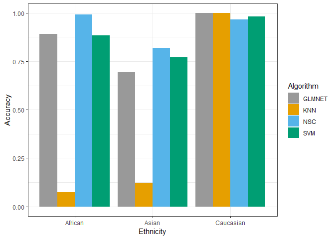

```r
class_acc <- z; rm(x,y,k,s,z)


#plot
cbPalette <- c("#999999", "#E69F00", "#56B4E9", "#009E73", "#F0E442", "#0072B2",
               "#D55E00", "#CC79A7")
ggplot(class_acc,
       aes(x = Ethnicity, y = Accuracy, fill = Algorithm)) +
  geom_bar(stat = 'identity', position = 'dodge') +
  theme_bw() + scale_fill_manual(values =  cbPalette)
```

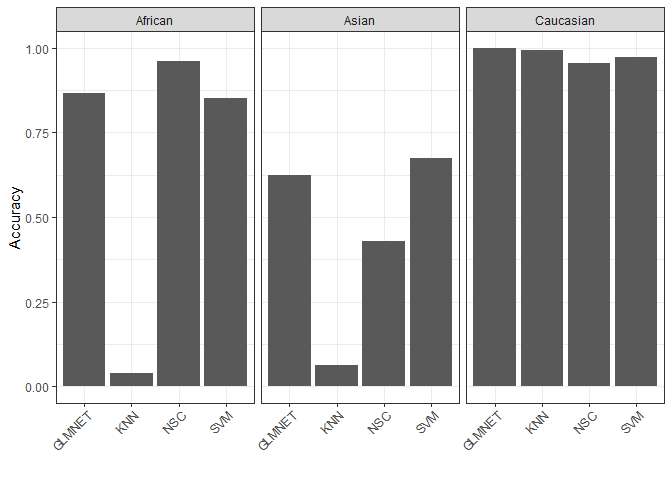

```r
g2 <- ggplot(class_acc, aes(x = Algorithm, y = Accuracy)) +
  geom_bar(stat = 'summary', fun.y = 'mean') +
  theme_bw() +
  theme(legend.position="none", axis.text.x = element_text(angle = 45, vjust = 1, hjust = 1)) +
  labs(x = '') + facet_wrap(~Ethnicity)
g2
```

```r
#ggbarplot(class_acc, x= 'Algorithm', y = 'Accuracy', color = 'Algorithm',
#          fill = 'Algorithm', facet.by = 'Ethnicity',
#          palette = 'jco',   position = position_dodge(0.75)) +
#  theme(legend.position="none", axis.text.x = element_text(angle = 45, vjust = 0.5)) +
#  labs(x = '')
class_acc %>% arrange(Algorithm, Ethnicity, fold)
```

```
##    Algorithm  fold    Accuracy Ethnicity
## 1     GLMNET fold1 0.891071429   African
## 2     GLMNET fold2 0.868000000   African
## 3     GLMNET fold3 0.876470588   African
## 4     GLMNET fold4 0.829545455   African
## 5     GLMNET fold5 0.865909091   African
## 6     GLMNET fold1 0.431428571     Asian
## 7     GLMNET fold2 0.692682927     Asian
## 8     GLMNET fold3 0.672727273     Asian
## 9     GLMNET fold4 0.665384615     Asian
## 10    GLMNET fold5 0.665000000     Asian
## 11    GLMNET fold1 0.997041420 Caucasian
## 12    GLMNET fold2 0.998351648 Caucasian
## 13    GLMNET fold3 0.996969697 Caucasian
## 14    GLMNET fold4 0.999208443 Caucasian
```

[output cut: 46 more lines]

ggsave(g2, filename = ‘../../Results/11_Class_specific_resampling_performance.tiff’)

I decide on glmnet in the end because it receives the least amount of skewing.

# 3.0 Outer CV

## 3.1 Accuracy / Kappa

Each sample is predicted it’s ethnicity by an independently generated classifier.

```r
res <- tibble(index = c(folds[[1]], folds[[2]], folds[[3]], folds[[4]], folds[[5]]),
       pred = c(predict(glm_fit1[[1]], betas[folds[[1]],]) %>% as.character(),
                predict(glm_fit1[[2]], betas[folds[[2]],]) %>% as.character(),
                predict(glm_fit1[[3]], betas[folds[[3]],]) %>% as.character(),
                predict(glm_fit1[[4]], betas[folds[[4]],]) %>% as.character(),
                predict(glm_fit1[[5]], betas[folds[[5]],]) %>% as.character()))

pDat$glm_pred[res$index] <- res$pred

cm <- confusionMatrix(as.factor(pDat$glm_pred), as.factor(pDat$Ethnicity2))
cm$byClass[1:3, 'Pos Pred Value'] %>% mean() # 0.9035936
```

```
## [1] 0.9035936
```

```r
cm
```

```
## Confusion Matrix and Statistics
##
##            Reference
## Prediction  African Asian Caucasian
##   African        52     0         4
##   Asian           0    36         7
##   Caucasian       5    17       378
##
## Overall Statistics
##
##                Accuracy : 0.9339
##                  95% CI : (0.9084, 0.954)
##     No Information Rate : 0.7796
##     P-Value [Acc > NIR] : < 2.2e-16
##
##                   Kappa : 0.8127
##  Mcnemar's Test P-Value : NA
##
## Statistics by Class:
##
##                      Class: African Class: Asian Class: Caucasian
## Sensitivity                  0.9123      0.67925           0.9717
## Specificity                  0.9910      0.98430           0.8000
## Pos Pred Value               0.9286      0.83721           0.9450
## Neg Pred Value               0.9887      0.96272           0.8889
## Prevalence                   0.1142      0.10621           0.7796
## Detection Rate               0.1042      0.07214           0.7575
## Detection Prevalence         0.1122      0.08617           0.8016
## Balanced Accuracy            0.9516      0.83178           0.8859
```

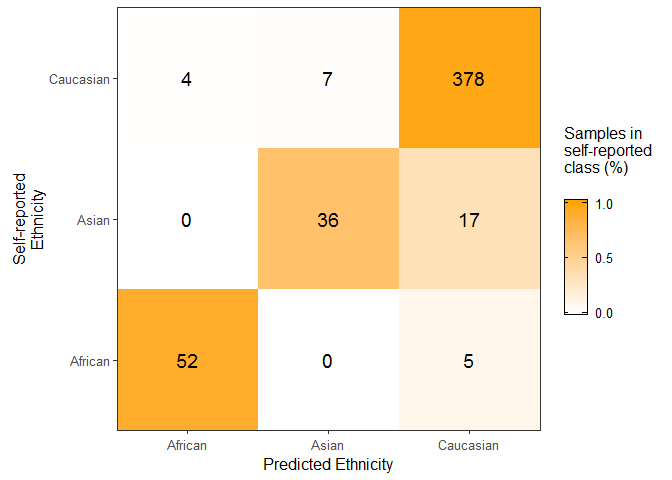

```r
cm_df <- as.data.frame(cm$table) %>%
  mutate(proportion = if_else(Reference == 'African', Freq/57, if_else(
    Reference == 'Asian', Freq/53, Freq/389))) %>%
  mutate(proportion_round = round(proportion, 3))

# prediction confusion matrix on test results
g3 <- ggplot(cm_df) +
  geom_tile(aes(x = Prediction, y = Reference, fill = proportion_round)) +
  geom_text(aes(x = Prediction, y = Reference, label = Freq), size = 5) +
  scale_fill_gradient2(low = "white", high = "orange", limits = c(0,1),
                       breaks = c(0, 0.5, 1.0),
                       guide = guide_colorbar(frame.colour = "black", ticks.colour = "black")) +
  #scale_x_discrete(labels=c(
  #  paste0('African\n(', round(cm$byClass[1,1]*100, 2), '%)'),
  #  paste0('Asian\n(', round(cm$byClass[2,1]*100, 2), '%)'),
  #  paste0('Caucasian\n(', round(cm$byClass[3,1]*100, 2), '%)'))) +
  theme_bw(base_size = 12) +
  scale_x_discrete(expand = c(0,0)) + scale_y_discrete(expand=c(0,0))+
  labs(fill = 'Samples in\nself-reported\nclass (%)\n',
       x = 'Predicted Ethnicity', y = 'Self-reported\nEthnicity') +
  coord_equal()
g3
```

ggsave(g3, filename = ‘../../Results/11_outerCV_cm_logLoss.tiff’, height = 6, width = 5.25)

## 3.2 Class probabilities

Here I look at the distribution of class probabilities.

**August 8th 2018 - probabilities may need ‘calibration’ (see http://danielnee.com/2014/10/calibrating-classifier-probabilties/).** Oct 2018 - Tried a bunch, couldn’t get something to work

```r
# get class probabilities
class_probs <- rbind(
  cbind(predict(glm_fit1[[1]], betas[folds[[1]],], type ='prob'), fold = 1),
  cbind(predict(glm_fit1[[2]], betas[folds[[2]],], type ='prob'), fold = 2),
  cbind(predict(glm_fit1[[3]], betas[folds[[3]],], type ='prob'), fold = 3),
  cbind(predict(glm_fit1[[4]], betas[folds[[4]],], type ='prob'), fold = 4),
  cbind(predict(glm_fit1[[5]], betas[folds[[5]],], type ='prob'), fold = 5))
class_probs <- class_probs %>% mutate(sampleNames = rownames(class_probs)) %>%
  rename(Prob_African = African, Prob_Asian = Asian,
         Prob_Caucasian = Caucasian)

#add to pDat
pDat <- pDat %>% inner_join(class_probs) %>% as_tibble()
```

## 3.3 Confidence thresholds

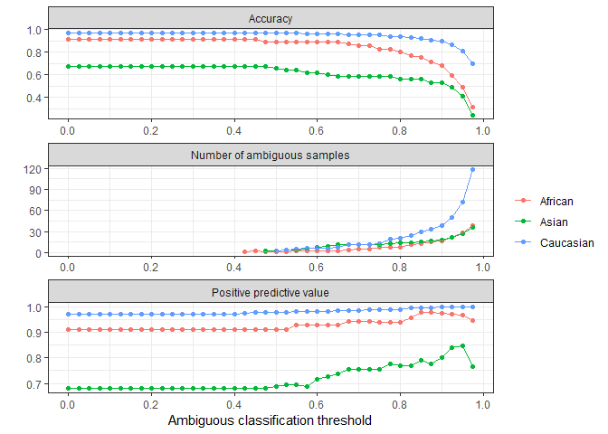

```r
# create a matrix of results to fill up
thresh <- seq(0, 1, 0.025)
thresholds <- tibble(thresholds = thresh,
                     Accuracy_AFR = rep(0, length(thresh)),
                     Accuracy_ASI = rep(0, length(thresh)),
                     Accuracy_CAU = rep(0, length(thresh)),
                     PPV_AFR = rep(0, length(thresh)),
                     PPV_ASI = rep(0, length(thresh)),
                     PPV_CAU = rep(0, length(thresh)),
                     Ambiguous_AFR = rep(0, length(thresh)),
                     Ambiguous_ASI = rep(0, length(thresh)),
                     Ambiguous_CAU = rep(0, length(thresh)))

# I need to choose what probability to compare the thresholds to. There are two options,
# 1) The class-specific probability that is the highest (most likely class)
# 2) The class-specific probability corresponding to the self-reported class
# I think 1) is less biased

pDat <- pDat %>%
  mutate(glm_pred = factor(glm_pred, levels = c('African', 'Asian', 'Caucasian')),
         Ethnicity2 = factor(Ethnicity2, levels = c('African', 'Asian', 'Caucasian')),
         # create a variable of the highest class-specific probability
         Highest_Prob = case_when(
           (Prob_African > Prob_Asian) &  (Prob_African > Prob_Caucasian) ~ Prob_African,
           (Prob_Asian > Prob_African) &  (Prob_Asian > Prob_Caucasian) ~ Prob_Asian,
           (Prob_Caucasian > Prob_African) &  (Prob_Caucasian > Prob_Asian) ~ Prob_Caucasian)) %>%
  as_tibble()

# fill up results matrix
for (i in 1:length(thresh)) {
  df <- pDat %>% select(Ethnicity2, glm_pred, Highest_Prob)
  df <- df %>% mutate(pred_thresh = case_when(
    Highest_Prob < thresh[i] ~ 'Ambiguous',
    Highest_Prob > thresh[i] ~ as.character(glm_pred)
  ))

  # class-specific accuracy
  correct <-  df %>% filter(Ethnicity2 == pred_thresh) %>% count(Ethnicity2) %>% pull(n)
  total <-  df %>% count(Ethnicity2) %>% pull(n)
  acc <- correct/total

  thresholds[i,2] <- acc[1]
  thresholds[i,3] <- acc[2]
  thresholds[i,4] <- acc[3]

  # class-specific PPV
  df2 <- df %>% filter(pred_thresh != 'Ambiguous')
  cm <- confusionMatrix(factor(df2$pred_thresh,  levels = c('African', 'Asian', 'Caucasian')),
                        factor(df2$Ethnicity2,  levels = c('African', 'Asian', 'Caucasian')))

  thresholds[i,5] <- cm$byClass[1,1] #African
  thresholds[i,6] <- cm$byClass[2,1] #Asian
  thresholds[i,7] <- cm$byClass[3,1] #Caucasian

  # number of ambiguous samples
  df2 <- df %>% filter(pred_thresh == 'Ambiguous') %>% count(Ethnicity2)
  thresholds[i, 8] <- df2[1,2] # African
  thresholds[i, 9] <- df2[2,2] # Asian
  thresholds[i, 10] <- df2[3,2] # caucasians

}

thresholds_plot <- as_tibble(melt(thresholds, id.vars = 'thresholds')) %>%
  separate(variable, into = c('Metric', 'Class')) %>%
  mutate(Class = case_when(
    Class == 'ASI' ~ 'Asian',
    Class == 'AFR' ~ 'African',
    Class == 'CAU' ~ 'Caucasian'
  ))


p <- ggplot(thresholds_plot %>% filter(thresholds != 1), aes(x = thresholds, y = value, col = Class)) +
  geom_point() + geom_line() + #geom_vline(xintercept = 0.6, col = 'red') +
  labs(y = '', x = 'Ambiguous classification threshold', col = '') +
  facet_wrap(~Metric, ncol = 1, scales = 'free',
             labeller = labeller(Metric = c(Accuracy = 'Accuracy',
                                            Ambiguous = 'Number of ambiguous samples',
                                            PPV = 'Positive predictive value'))) +
  scale_x_continuous(breaks = seq(0,1,0.2)) +
  theme(legend.position = 'bottom') + theme_bw();p
```

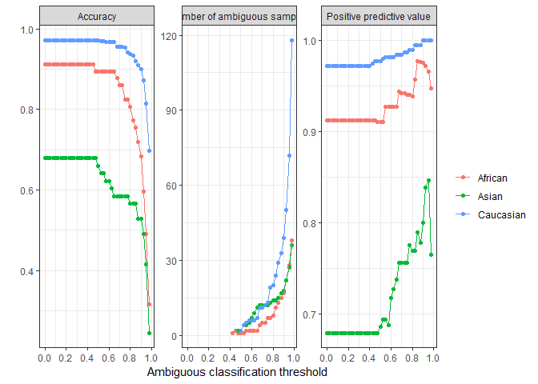

```r
p2 <- ggplot(thresholds_plot %>% filter(thresholds != 1), aes(x = thresholds, y = value, col = Class)) +
  geom_point() + geom_line() + #geom_vline(xintercept = 0.6, col = 'red') +
  labs(y = '', x = 'Ambiguous classification threshold', col = '') +
  facet_wrap(~Metric, ncol = 3, scales = 'free',
             labeller = labeller(Metric = c(Accuracy = 'Accuracy',
                                            Ambiguous = 'Number of ambiguous samples',
                                            PPV = 'Positive predictive value'))) +
  scale_x_continuous(breaks = seq(0,1,0.2)) +
  theme(legend.position = 'bottom') + theme_bw();p2
```

```r
thresholds_plot %>% filter(thresholds < 0.625 & thresholds > 0.58)
```

```
## # A tibble: 9 x 4
##   thresholds Metric    Class     value
##        <dbl> <chr>     <chr>     <dbl>
## 1        0.6 Accuracy  African   0.895
## 2        0.6 Accuracy  Asian     0.623
## 3        0.6 Accuracy  Caucasian 0.967
## 4        0.6 PPV       African   0.927
## 5        0.6 PPV       Asian     0.717
## 6        0.6 PPV       Caucasian 0.982
## 7        0.6 Ambiguous African   2
## 8        0.6 Ambiguous Asian     7
## 9        0.6 Ambiguous Caucasian 6
```

```r
thresholds_plot %>% filter(thresholds < 0.005 )
```

```
## # A tibble: 9 x 4
##   thresholds Metric    Class      value
##        <dbl> <chr>     <chr>      <dbl>
## 1          0 Accuracy  African    0.912
## 2          0 Accuracy  Asian      0.679
## 3          0 Accuracy  Caucasian  0.972
## 4          0 PPV       African    0.912
## 5          0 PPV       Asian      0.679
## 6          0 PPV       Caucasian  0.972
## 7          0 Ambiguous African   NA
## 8          0 Ambiguous Asian     NA
## 9          0 Ambiguous Caucasian NA
```

The real benefit here is that the self-reported labels cannot be considered the ground ‘truth’, and likely many samples are truly epigenetic / genetic mixtures between ethnicities.

```r
## Threshold at 0.75
pDat <- pDat %>%
  mutate(Predicted_ethnicity = case_when(
      Highest_Prob > 0.75 ~ as.character(glm_pred),
      Highest_Prob < 0.75 ~ 'Ambiguous'))

############ create confusion matrix
levels <- c("African", "Asian", "Caucasian", "Ambiguous")
cm3 <- confusionMatrix(factor(pDat$Predicted_ethnicity, levels = levels),
                reference = factor(pDat$Ethnicity2, levels = levels))
cm_df_thresh <- cm3$table %>% as.data.frame() %>%
  filter(Reference != 'Ambiguous') %>%
  mutate(proportion = case_when(
    Reference=='African' ~ Freq/57,
    Reference=='Asian' ~ Freq/53,
    Reference=='Caucasian'~ Freq/389
  ))
acc <- cm3$overall
cm3$byClass[1:3, 'Pos Pred Value'] %>% mean() # Pos Pred Value 0.9436756
```

```
## [1] 0.9436756
```

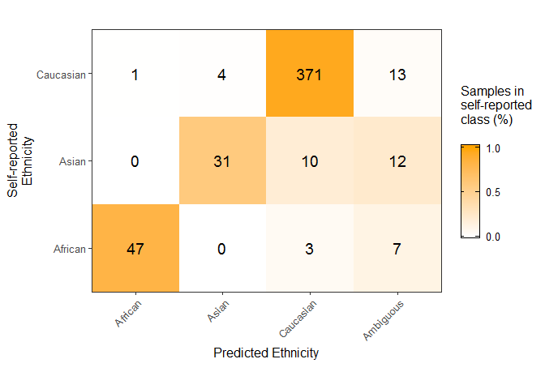

```r
ggplot(cm_df_thresh) +
  geom_tile(aes(x = Prediction, y = Reference, fill = proportion)) +
  geom_text(aes(x = Prediction, y = Reference, label = Freq), size = 5) +
  scale_fill_gradient2(low = "white", high = "orange", limits = c(0,1),
                       breaks = c(0, 0.5, 1.0),
                       guide = guide_colorbar(frame.colour = "black", ticks.colour = "black")) +
  theme_bw(base_size = 12) +
  theme(axis.text.x = element_text(angle = 45, vjust = 1, hjust = 1)) +
  scale_x_discrete(expand = c(0,0)) +
  scale_y_discrete(expand=c(0,0))+
  labs(fill = 'Samples in\nself-reported\nclass (%)\n',
       x = 'Predicted Ethnicity', y = 'Self-reported\nEthnicity') +
  coord_equal()
```

saveRDS(pDat %>% select(-PredictedSex), ‘../../Robjects_final/02_pDat.rds’) pDat <- readRDS(‘../../Robjects_final/02_pDat.rds’)

For each dataset

```r
# add dataset identifiers
pDat <- pDat %>% mutate(Cohort = case_when(
    Dataset == 'Michels' ~ 'GSE70453',
    Dataset == 'Fry' ~ 'GSE73375',
    Dataset == 'Robinson' ~ 'GSE100197, GSE108567, GSE74738',
    Dataset == 'Marsit' ~ 'GSE75248' ,
    Dataset == 'Cox' ~ 'GSE98224'),
  Cohort = case_when(
    Dataset == 'Michels' ~ 'C1',
    Dataset == 'Fry' ~ 'C2',
    Dataset == 'Robinson' ~ 'C5',
    Dataset == 'Marsit' ~ 'C3' ,
    Dataset == 'Cox' ~ 'C4'))

# generate confusion matrix by cohort
for (i in levels(as.factor(pDat$Cohort))) {

  #filter down to samples for a specific cohort
  p <- pDat %>% filter(Cohort == i)

  # calculate confusion matrix
  cm <-confusionMatrix(factor(p$Predicted_ethnicity, levels = levels),
                       reference = factor(p$Ethnicity2, levels = levels))

  # pull out count table of reference classes to calculate proportions
  fr <- table(factor(p$Ethnicity2, levels = levels))

  # convert to plottable format and add proportion column
  cmt <- cm$table %>% as.data.frame() %>%
    filter(Reference != 'Ambiguous') %>%
    mutate(proportion = case_when(
              Reference=='African' ~ Freq/fr[1],
              Reference=='Asian' ~ Freq/fr[2],
              Reference=='Caucasian'~ Freq/fr[3]),
           Cohort = i)

  # grow with each iteration
  if (i == 'C1') {
    cm_by_dataset <- cmt
    perf_by_dataset <- t(data.frame(c(Dataset = 'C1', cm$overall[1:2])))
  } else{
    cm_by_dataset <- rbind(cm_by_dataset, cmt)
    perf_by_dataset <- rbind(perf_by_dataset, t(data.frame(c(Dataset = i, cm$overall[1:2]))))
  }

}
perf_by_dataset <- as_tibble(perf_by_dataset) %>%
  mutate(Accuracy = as.numeric(Accuracy), Kappa = as.numeric(Kappa))
perf_by_dataset
```

```
## # A tibble: 5 x 3
##   Dataset Accuracy Kappa
##   <chr>      <dbl> <dbl>
## 1 C1         0.806 0.652
## 2 C2         0.917 0.85
## 3 C3         0.927 0.711
## 4 C4         0.795 0.610
## 5 C5         0.943 0.851
```

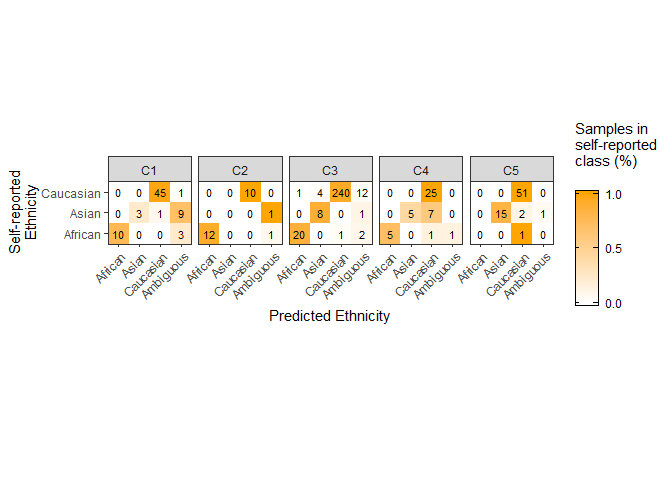

```r
ggplot(cm_by_dataset) +
  geom_tile(aes(x = Prediction, y = Reference, fill = proportion)) +
  geom_text(aes(x = Prediction, y = Reference, label =  Freq), size = 3) +
  scale_fill_gradient2(low = "white", high = "orange", limits = c(0,1),
                       breaks = c(0, 0.5, 1.0),
                       guide = guide_colorbar(frame.colour = "black", ticks.colour = "black")) +
  theme_bw(base_size = 11) +
  theme(axis.text.x = element_text(angle = 45, vjust = 1, hjust = 1)) +
  scale_x_discrete(expand = c(0,0)) +
  scale_y_discrete(expand=c(0,0))+
  labs(fill = 'Samples in\nself-reported\nclass (%)\n',
       x = 'Predicted Ethnicity', y = 'Self-reported\nEthnicity') +
  coord_equal() +
  facet_grid(~Cohort)
```

write.table(perf_by_dataset, ‘../../Performance_by_dataset.txt’, quote = F, row.names= F) write.table(cm_by_dataset, ‘../../Performance_by_dataset.txt’, quote = F, row.names= F)

## 3.4 missclassifications

Here I examine missclassifications by projecting samples on ancestry coordinates and examining the relationship between probability estimates and these coordinates.

First I hypothesize that incorrectly predicted samples have less confident predictions (lower probability)

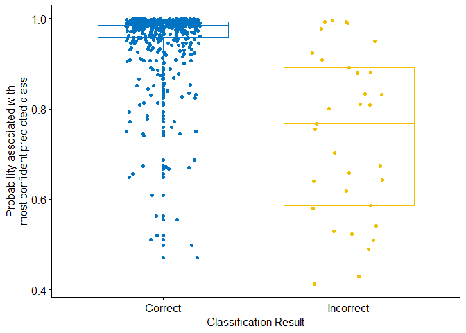

```r
# load aims data
aims_plomics <- read.csv('../../data/Robinson/AIMs/MDSCOORD_AIMsWR-P2.csv')
aims_rob <- read.csv('../../data/Robinson/AIMs/ROBLAB.MDS.noAMR.csv')

# merge the two
aims <- rbind(aims_plomics, aims_rob) %>% as_tibble() %>%
  mutate(sampleNames = gsub('v$', '', X)) %>% rename(SampleID = sampleNames)

# create some probability thresholds to plot with
pDat <- pDat %>%
# First I make a new variable of the probability associated with the most confident predicted class
# I make a variable that is the exact value, and then another that is categorical
  mutate(Prob_High_con = if_else(Prob_African > Prob_Asian &
                                  Prob_African > Prob_Caucasian, Prob_African,
                        if_else(Prob_Asian > Prob_African &
                                  Prob_Asian > Prob_Caucasian, Prob_Asian, Prob_Caucasian)),
         Prob_High_cat = if_else(Prob_High_con > 0.9, '> 90%',
                                 if_else(Prob_High_con > 0.75, '> 75%',
                                         if_else(Prob_High_con > 0.5, '> 50%', '< 50%'))),
# Next I make another new variable of the probability of being correctly predicted
         Prob_correct_con = if_else(Ethnicity2 == 'African', Prob_African,
                                if_else(Ethnicity2 == 'Asian', Prob_Asian, Prob_Caucasian)),
         Prob_correct_cat = if_else(Prob_correct_con > 0.9, '> 90%',
                                 if_else(Prob_correct_con > 0.75, '> 75%',
                                         if_else(Prob_correct_con > 0.5, '> 50%', '< 50%'))))

# Now I separate samples by those that were incorrectly/correctly predicted
pDat <- pDat %>% mutate(Prediction_result = if_else(Ethnicity2 == glm_pred, 'Correct', 'Incorrect'))

ggboxplot(pDat, x = 'Prediction_result', y = 'Prob_High_con',
          add = 'jitter', color = 'Prediction_result', palette = 'jco',
          ylab = 'Probability associated with\nmost confident predicted class',
          xlab = 'Classification Result') +
  theme(legend.position = 'none')
```

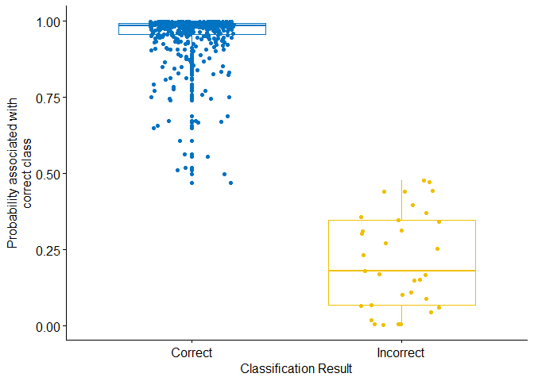

```r
ggboxplot(pDat, x = 'Prediction_result', y = 'Prob_correct_con',
          add = 'jitter', color = 'Prediction_result', palette = 'jco',
          ylab = 'Probability associated with\ncorrect class',
          xlab = 'Classification Result') +
  theme(legend.position = 'none')
```

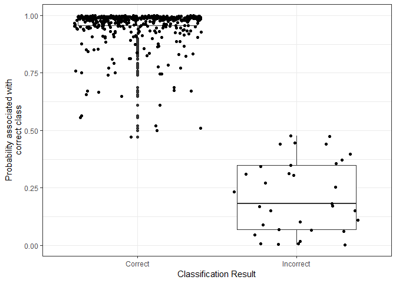

```r
ggplot(pDat, aes(x = Prediction_result, y = Prob_correct_con)) +
  geom_boxplot() + theme_bw() + geom_jitter() +
  labs(y = 'Probability associated with\ncorrect class', x = 'Classification Result')
```

```r
# statistically signficant?
wilcox.test(pDat %>% filter(Prediction_result == 'Correct') %>% pull(Prob_High_con),
            pDat %>% filter(Prediction_result == 'Incorrect') %>% pull(Prob_High_con),
            alternative = "two.sided")
```

```
##
##  Wilcoxon rank sum test with continuity correction
##
## data:  pDat %>% filter(Prediction_result == "Correct") %>% pull(Prob_High_con) and pDat %>% filter(Prediction_result == "Incorrect") %>% pull(Prob_High_con)
## W = 13195, p-value = 6.076e-12
## alternative hypothesis: true location shift is not equal to 0
```

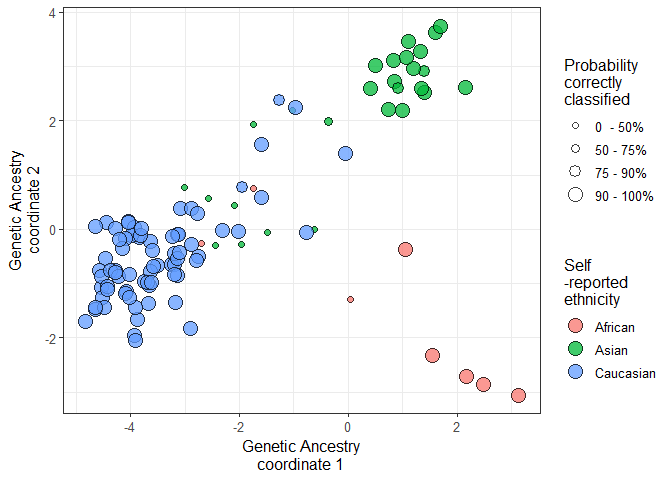

```r
#ggsave(plot = g7, filename = '../../Results/11_HighestProb_logLoss.tiff')

# Now plot on genetic ancestry coordinates
#take out those samples that have aims and methylation data
df <- pDat %>% select(contains('Prob'), Ethnicity2, sampleNames) %>%
  inner_join(aims %>% mutate(sampleNames = SampleID) %>%
               select(contains('Coord'), sampleNames))
ggplot(df, aes(x=Coordinate1,y=Coordinate2)) +
  geom_point(aes(fill = Ethnicity2, size = Prob_correct_cat), pch = 21, alpha = 0.75) +
  scale_size_manual(values = c('< 50%' =2 , '> 50%' = 3, '> 75%' = 4,
                                '> 90%' = 5),
                    labels = c('0  - 50%', '50 - 75%', '75 - 90%', '90 - 100%')) +
  labs(size = '\nProbability\ncorrectly\nclassified',
       fill = '\nSelf\n-reported\nethnicity',
       x = 'Genetic Ancestry\ncoordinate 1', y = 'Genetic Ancestry\ncoordinate 2') +
  guides(fill = guide_legend(override.aes = list(size=5))) +
  theme_bw(base_size = 12);
```

# 4.0 Final training

Now I rebuild a final Algorithmrithm using the model building procedure evaluated above.

```r
#setup parallel, resampling, seeds, tuninggrid
cluster <- makeCluster(16)
registerDoParallel(cluster)

seeds <- list()
set.seed(300)
for (i in 1:30) seeds[[i]] <- sample.int(1000, 81)
seeds[[31]] <- sample.int(1000,1)
fitControl <- trainControl(method = "repeatedcv", number = 3, repeats = 10,
                           allowParallel = T, classProbs = T, returnData = F,
                           savePredictions = 'final', returnResamp = 'final',
                           summaryFunction = mnLogLoss, seeds = seeds)
NSCGrid <- data.frame(threshold = seq(0,10, 0.125))

#train
NSC_cv <- train(x = betas, y = pDat$Ethnicity2,
                 method = "pam",
                 metric = 'logLoss',
                 trControl = fitControl,
                 tuneGrid = NSCGrid)
stopCluster(cluster)
```

saveRDS(NSC_cv, ‘../../Robjects_final/02_NSC_cv_logloss.rds’)

```r
# configure parallel processing
cluster <- makeCluster(16) # ram is limiting
# at peak around 6.5 - 7 gb is used in an instance
registerDoParallel(cluster)

# create seeds for each resample
seeds <- list()
set.seed(11)
for (j in 1:30) seeds[[j]] <- sample.int(1000, 96)
seeds[[31]] <- sample.int(1000,1)

# tuning grid
glmGrid <-  expand.grid(alpha = c(0.025, 0.05, 0.1, 0.15, 0.2, 0.25, 0.3, 0.5),
                        lambda = c(0.0025, 0.005, 0.01, 0.05, 0.1, 0.25))
fitControl <- trainControl(method = "repeatedcv", number = 3, repeats = 10,
                           allowParallel = T, classProbs = T, returnData = F,
                           savePredictions = 'final', returnResamp = 'final',
                           summaryFunction = mnLogLoss, seeds = seeds)

GLM_cv <- train(x = betas, y = pDat$Ethnicity2,
                 method = "glmnet",
                 metric = 'logLoss',
                 trControl = fitControl,
                 tuneGrid = glmGrid)

#user  system elapsed
 #300.36  164.57 5274.27
stopCluster(cluster)
saveRDS(GLM_cv, '../../Robjects_final/02_GLM_cv_logloss.rds')
```

```r
GLM_cv <- readRDS('../../Robjects_final/02_GLM_cv_logloss.rds')
```

## 4.1 Feature analysis

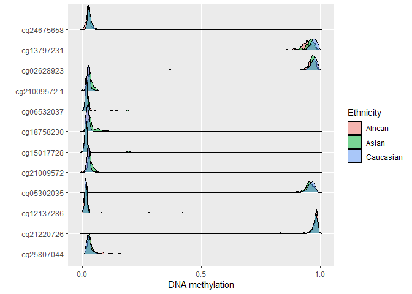

```r
# Calculate the 'importance' for each predictor. This is related to the centroid distance for each
# class
glm_features <- varImp(GLM_cv)
glm <- glm_features$importance
glm$features <- rownames(glm)
glm <- glm %>% mutate(features = rownames(glm)) %>% as_tibble() %>%
  filter(Asian > 0 | African > 0 | Caucasian > 0) %>% arrange(desc(African)) # remove non-predictors

# pull the top 4 predictors for each class
glm_afr_4 <- glm %>% filter(grepl('cg', features)) %>% slice(1:4) %>% pull(features)
glm_asi_4 <- glm %>% filter(grepl('cg', features)) %>% arrange(desc(Asian)) %>% slice(1:4) %>% pull(features)
glm_cau_4 <- glm %>% filter(grepl('cg', features)) %>% arrange(desc(Caucasian)) %>% slice(1:4) %>% pull(features)

# plot top 4 predictors of each class
plot_data <-betas[,c(glm_afr_4, glm_asi_4, glm_cau_4)] %>% mutate(Ethnicity = pDat$Ethnicity2) %>%
  melt() %>% as_tibble()
plot1 <- ggplot(plot_data, aes(x = value, y = variable)) +
  geom_density_ridges(aes(fill = Ethnicity), alpha = 0.5) +
  labs(x = 'DNA methylation', y = '') +
  scale_x_continuous(breaks = c(0, 0.5, 1));plot1
```

```r
# Figure out how many sites fall into each category
length(glm$features)#1860
```

```
## [1] 1860
```

```r
sum(grepl('rs', glm$features))# 15 are rs probes
```

```
## [1] 15
```

```r
# load 450k annotations to figure out if any annotated SNPs lie in the probe body
library(IlluminaHumanMethylation450kanno.ilmn12.hg19)
data(IlluminaHumanMethylation450kanno.ilmn12.hg19)
anno <-  getAnnotation(IlluminaHumanMethylation450kanno.ilmn12.hg19)
anno$CpG <- rownames(anno)

#filter out relevant columns
anno <- anno %>% as_tibble() %>%
  select(CpG, chr, pos, strand, Probe_rs, Probe_maf, CpG_rs, CpG_maf,
         SBE_rs, SBE_maf, Islands_Name, Relation_to_Island,
         UCSC_RefGene_Name, UCSC_RefGene_Accession, UCSC_RefGene_Group,
         Phantom, DMR, Enhancer, HMM_Island, Regulatory_Feature_Name,
         Regulatory_Feature_Group, DHS)
# filter out to only those in glm predictor (explicit rs probes excluded)
anno_glm <- anno %>% filter(CpG %in% glm$features)

# Catherine Do et al 2018 placental mQTLs
cdo <- read_xlsx('../../data/C Do et al 2018/journal.pgen.1007785.s018.xlsx')
length(intersect(anno_glm$CpG, cdo$cpgID)) # 220 / 4342
```

```
## [1] 220
```

```r
anno_glm <- anno_glm %>%
  mutate(CDo_2016_pl_mQTLs = ifelse(CpG %in% cdo$cpgID, 1, 0))

# ALSPAC birth / cord blood mQTLs
alspac <- as_tibble(read.table('../../data/ALSPAC mQTLs/cord.ALL.M.tab'), header = TRUE)
colnames(alspac) <- as.character(t(alspac[1, ])) # the first row will be the header
alspac <- alspac[-1, ]          # removing the first row.
#fix variable classes
alspac2 <- alspac %>% mutate_at(vars(beta:FDR), as.character) %>% mutate_if(is.character, as.numeric)
alspac3 <- alspac2 %>% filter(`p-value` < 1e-14) %>% pull(gene) %>% as.character
length(intersect(anno_glm$CpG, alspac3)) #242 / 27992
```

```
## [1] 242
```

```r
anno_glm <- anno_glm %>% mutate(ALSPAC_mQTL = ifelse(CpG %in% alspac3, 1, 0))

# our pilot study
roblab <- read_xlsx('../../Results/16_mQTL_results.xlsx')
length(intersect(anno_glm$CpG, roblab$cpg)) # 147 / 2461
```

```
## [1] 147
```

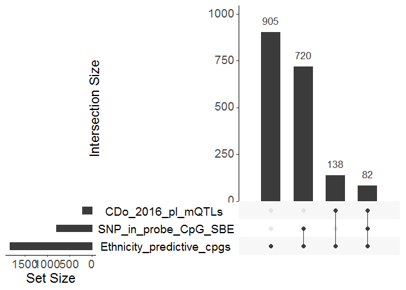

```r
anno_glm <- anno_glm %>% mutate(roblab_pilot_mQTL = ifelse(CpG %in% roblab$cpg, 1, 0))

# aggregate mQTL (-roblab b/c unpublished) into one column, and snp in probe/cpg/sbe into one
anno_glm <- anno_glm %>%
  mutate(mQTL = ifelse(CDo_2016_pl_mQTLs == 1 | ALSPAC_mQTL == 1, 1, 0),
         SNP_in_probe_CpG_SBE = if_else(Probe_maf > 0.01 | CpG_maf > 0.01 | SBE_maf > 0.01, 1, 0,
                                        missing = 0))

glm_upset <- anno_glm %>%
  mutate(RS_probe = if_else(Probe_maf > 0.01, 1, 0, missing = 0),
         RS_CpG = if_else(CpG_maf > 0.01, 1, 0, missing = 0),
         RS_SBE = if_else(SBE_maf > 0.01, 1, 0, missing = 0)) %>%
  select(CpG, RS_probe, RS_CpG, RS_SBE, contains('mQTL'), SNP_in_probe_CpG_SBE) %>%
  mutate(Ethnicity_predictive_cpgs = 1)

upset(as.data.frame(glm_upset), sets = c('Ethnicity_predictive_cpgs',
                                         'SNP_in_probe_CpG_SBE', 'CDo_2016_pl_mQTLs'),
      keep.order = T, text.scale = 2)
```

```r
# number of probes with snp in probe / cpg / sbe position
sum(anno_glm$SNP_in_probe_CpG_SBE == 1) # 802
```

```
## [1] 802
```

```r
anno_glm_all <- glm[,c(4,1:3)] %>% rename(Importance_African = African,
                          Importance_Asian = Asian,
                          Importance_Caucasian = Caucasian) %>%
  full_join(anno_glm %>% select(-ALSPAC_mQTL, -roblab_pilot_mQTL, -mQTL, -SNP_in_probe_CpG_SBE),
            by = c('features' = 'CpG'))

# total number of genetic and non-genetic cpgs fed to classifier
genetic_cpgs1 <- anno %>% filter(CpG %in% colnames(betas)) %>%
  filter(Probe_maf > 0.01 | CpG_maf > 0.01 | SBE_maf > 0.01) %>%
  pull(CpG)

# num of cpgs with snps in probe
length(genetic_cpgs1) # 64821
```

```
## [1] 64821
```

```r
# num of cpgs that are placental mqtl
length(unique(cdo$cpgID)) # 4342
```

```
## [1] 4342
```

```r
# genetic probes = the union of above (addition minus overlap)
length(union(genetic_cpgs1, cdo$cpgID)) # 68062
```

```
## [1] 68062
```

```r
# number of non-genetic probes
length(colnames(betas)) - length(union(genetic_cpgs1, cdo$cpgID)) # 251171
```

```
## [1] 251171
```

```r
# test of significance
# genetic cpgs:
fisher.test(matrix(c(940,68062,905,251171),nrow=2,ncol=2),alternative="greater")
```

```
##
##  Fisher's Exact Test for Count Data
##
## data:  matrix(c(940, 68062, 905, 251171), nrow = 2, ncol = 2)
## p-value < 2.2e-16
## alternative hypothesis: true odds ratio is greater than 1
## 95 percent confidence interval:
##  3.54528     Inf
## sample estimates:
## odds ratio
##   3.833129
```

```r
# rs probes
fisher.test(matrix(c(15,59,1845,319174),nrow=2,ncol=2),alternative="greater")
```

```
##
##  Fisher's Exact Test for Count Data
##
## data:  matrix(c(15, 59, 1845, 319174), nrow = 2, ncol = 2)
## p-value < 2.2e-16
## alternative hypothesis: true odds ratio is greater than 1
## 95 percent confidence interval:
##  25.66153      Inf
## sample estimates:
## odds ratio
##   43.95978
```

```r
# mqtls
cpgs <- colnames(betas)[!grepl('rs', colnames(betas))]
length(cpgs) # 319174
```

```
## [1] 319174
```

```r
length(intersect(cdo$cpgID, cpgs)) # 3689 num of mqtls fed to classifier
```

```
## [1] 3689
```

```r
length(intersect(cdo$cpgID, cpgs))  - 220 # 3469 num mqtls not used by classifier
```

```
## [1] 3469
```

```r
length(setdiff(cpgs, cdo$cpgID)) # 315485 num of non-mqtls fed to classifier
```

```
## [1] 315485
```

```r
1845-220 # 1625 num of non-mqtls fed to classifier
```

```
## [1] 1625
```

```r
fisher.test(matrix(c(220,3469,1625,315485),nrow=2,ncol=2),alternative="greater")
```

```
##
##  Fisher's Exact Test for Count Data
##
## data:  matrix(c(220, 3469, 1625, 315485), nrow = 2, ncol = 2)
## p-value < 2.2e-16
## alternative hypothesis: true odds ratio is greater than 1
## 95 percent confidence interval:
##  10.86042      Inf
## sample estimates:
## odds ratio
##   12.31318
```

```r
# tech genetic cpgs
fisher.test(matrix(c(802, 64821, 1043, 254353), nrow = 2, ncol=2), alternative="greater")
```

```
##
##  Fisher's Exact Test for Count Data
##
## data:  matrix(c(802, 64821, 1043, 254353), nrow = 2, ncol = 2)
## p-value < 2.2e-16
## alternative hypothesis: true odds ratio is greater than 1
## 95 percent confidence interval:
##  2.788528      Inf
## sample estimates:
## odds ratio
##   3.017189
```

write.table(anno_glm_all, ‘../../Robjects_final/02_glm_features.txt’, sep = ‘’, quote = F, row.names = F)

# 5.0 compare to zhou’s classifier

```r
# load data
ss_Rob <- read.metharray.sheet(base = '../../data/Robinson/IDATs', recursive = T)
ss_Cox <- read.metharray.sheet('../../data/Cox', pattern = 'des')
idat_Mar <- searchIDATprefixes('../../data/GSE75248 - Marsit/IDATS')

# load idats and predict ethnicity
sset_R <- lapply(ss_Rob$Basename, readIDATpair)
robeth <- lapply(sset_R, inferEthnicity)
robeth <- ss_Rob %>% as_tibble() %>% select(sampleNames, Ethnicity) %>%
  mutate(Predicted_ethnicity_zhou = unlist(robeth))

sset_C <- lapply(ss_Cox$Basename, readIDATpair)
coxeth <- lapply(sset_C, inferEthnicity)
coxeth <- ss_Cox %>% as_tibble() %>% select(ParticipantID, Ethnicity) %>%
  mutate(Predicted_ethnicity_zhou = unlist(coxeth))

rm(sset_R, sset_C)
library(stringr)
sset_M <- lapply(idat_Mar, readIDATpair) # 28 gb
mareth <- lapply(sset_M, inferEthnicity)
mareth <- tibble(sampleNames = str_extract(names(unlist(mareth)),'GSM[0-9]*'),
       Predicted_ethnicity_zhou = unlist(mareth))

# add ethnicity info
mareth <- mareth %>% inner_join(pDat %>% select(sampleNames, Ethnicity))
zhou_predictions <- rbind(mareth, robeth, coxeth %>% rename(sampleNames = ParticipantID))

# add glm predicted info
zhou_predictions<- zhou_predictions %>% inner_join(pDat %>% select(sampleNames, glm_pred, Cohort))

# calculate confusion matrix
zhou_predictions <- zhou_predictions %>%
  mutate(Ethnicity = ifelse(Ethnicity == 'Black', 'African',
                            ifelse(Ethnicity == 'East_Asian', 'Asian', Ethnicity)),
         Predicted_ethnicity_zhou2 = ifelse(Predicted_ethnicity_zhou == 'WHITE', 'Caucasian',
                                            ifelse(Predicted_ethnicity_zhou == 'ASIAN', 'Asian',
                                                   'African')))
levels <- c('African', 'Asian', 'Caucasian')
cm4 <- confusionMatrix(factor(zhou_predictions$Predicted_ethnicity_zhou2, levels = levels),
                reference = factor(zhou_predictions$Ethnicity, levels = levels))
cm5 <- confusionMatrix(factor(zhou_predictions$glm_pred, levels = levels),
                reference = factor(zhou_predictions$Ethnicity, levels = levels))

# combine confusion matrix for both predictors
cm_z <- rbind(cm4$table %>% as.data.frame() %>% mutate(Algorithm = 'Zhou et al. 2018') %>%
                mutate(Prediction = case_when(
                  Prediction == 'African' ~ 'BLACK',
                  Prediction == 'Caucasian' ~ 'WHITE',
                  Prediction == 'Asian' ~ 'ASIAN')),
              cm5$table %>% as.data.frame() %>% mutate(Algorithm = 'GLMNET')) %>%
  group_by(Algorithm, Reference) %>%
  mutate(proportion = Freq/sum(Freq)) %>% ungroup() %>%
  mutate(Prediction = factor(Prediction, levels = c('African', 'Asian', 'Caucasian',
                                                    'BLACK', 'ASIAN',
                                                    'WHITE')))

#plot
ggplot(cm_z) +
  geom_tile(aes(x = Prediction, y = Reference, fill = proportion)) +
  geom_text(aes(x = Prediction, y = Reference, label = Freq), size = 5) +
  facet_grid(~Algorithm, scales = 'free') +
  scale_fill_gradient2(low = "white", high = "orange", limits = c(0,1),
                       breaks = c(0, 0.5, 1.0),
                       guide = guide_colorbar(frame.colour = "black", ticks.colour = "black")) +
  theme_bw(base_size = 12) +
  theme(axis.text.x = element_text(angle = 45, vjust = 1, hjust = 1)) +
  scale_x_discrete(expand = c(0,0)) +
  scale_y_discrete(expand=c(0,0))+
   labs(fill = 'Samples in\nself-reported\nclass (%)\n',
       x = 'Predicted Ethnicity', y = 'Self-reported\nEthnicity')

#print performance metrics
cm4 # zhou
cm5 # placental predictor
```

[output not shown]